# Assignment: Among Site (Beta) Diversity

### ii. Constrained Ordination

In the R code chunk below, do the following:

1. create an environmental matrix of the water chemistry data included in the `doubs` dataset using forward and reverse selection of variables,
2. conduct a redundancy analysis on the fish assemblages of the Doubs River,
3. use a permutation test to determine the significance of the constrained analysis,
4. use a permutation test to determine the correlation of each environmental factor on the constrained axes,
5. calculate the explained variation on the first and second constrained axes,
6. plot the constrained ordination results including labeled points for each site, and
7. add vectors that demonstrate the influence of each environmental factor the constrained ordination.

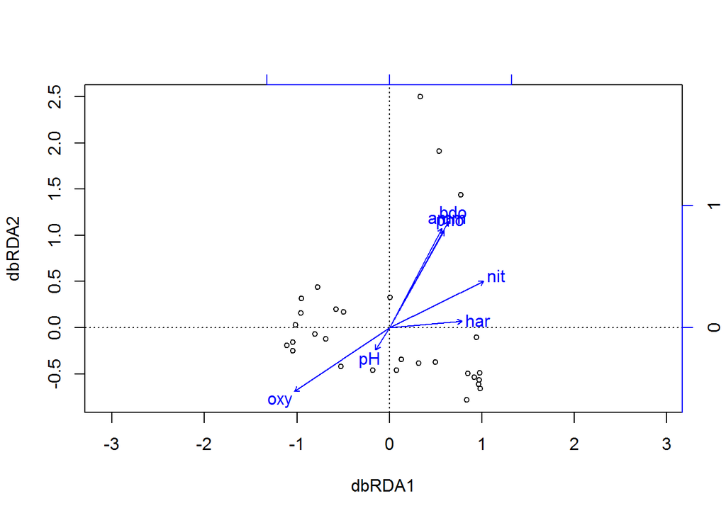

```r
#make envtl matrix
env.chem <- as.matrix(doubs$env[-8 , 5:11])
#dbRDA, redundancy analysis
doubs.dbrda <- dbrda(fish.db ~ ., as.data.frame(env.chem))
ordiplot(doubs.dbrda)
```

```r
psych::corr.test(env.chem)
```

```
## Call:psych::corr.test(x = env.chem)
## Correlation matrix
##        pH   har   pho   nit   amm   oxy   bdo
## pH   1.00  0.08 -0.08 -0.04 -0.12  0.19 -0.16
## har  0.08  1.00  0.37  0.53  0.30 -0.37  0.34
## pho -0.08  0.37  1.00  0.80  0.97 -0.76  0.91
## nit -0.04  0.53  0.80  1.00  0.80 -0.69  0.68
## amm -0.12  0.30  0.97  0.80  1.00 -0.75  0.90
## oxy  0.19 -0.37 -0.76 -0.69 -0.75  1.00 -0.84
## bdo -0.16  0.34  0.91  0.68  0.90 -0.84  1.00
## Sample Size
## [1] 29
## Probability values (Entries above the diagonal are adjusted for multiple tests.)
##       pH  har  pho  nit  amm  oxy  bdo
## pH  0.00 1.00 1.00 1.00 1.00 1.00 1.00
## har 0.66 0.00 0.46 0.03 0.83 0.46 0.59
## pho 0.68 0.05 0.00 0.00 0.00 0.00 0.00
## nit 0.83 0.00 0.00 0.00 0.00 0.00 0.00
## amm 0.53 0.12 0.00 0.00 0.00 0.00 0.00
## oxy 0.32 0.05 0.00 0.00 0.00 0.00 0.00
## bdo 0.40 0.07 0.00 0.00 0.00 0.00 0.00
##
##  To see confidence intervals of the correlations, print with the short=FALSE option
```

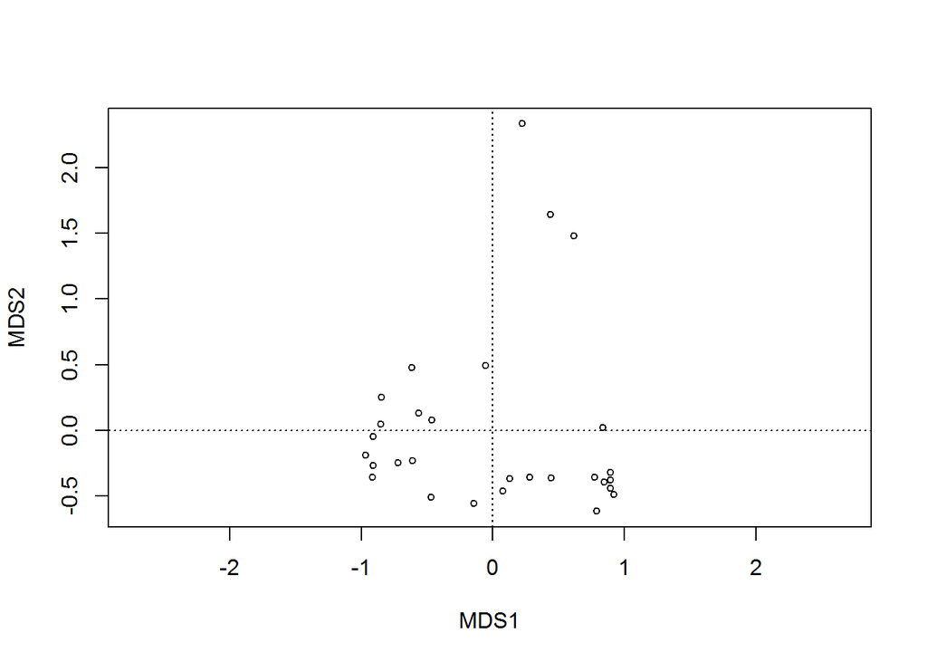

```r
#nit, amm, oxy, bdo are all significantly correlated with one another.
#let's be more parsimonious and use fewer variables---avoid model overfitting
# First, we will model only the intercept
doubs.dbrda.mod0 <- dbrda(fish.db ~ 1, as.data.frame(env.chem))

ordiplot(doubs.dbrda.mod0)
```

```r
#the full model:
doubs.dbrda.mod1 <- dbrda(fish.db ~ ., as.data.frame(env.chem))
# Now step through all combinations of explanatory variables
doubs.dbrda <- ordiR2step(doubs.dbrda.mod0, doubs.dbrda.mod1, perm.max = 200)
```

```
## Step: R2.adj= 0
## Call: fish.db ~ 1
##
##                 R2.adjusted
## <All variables>  0.53032584
## + oxy            0.27727176
## + nit            0.25755208
## + bdo            0.17477787
## + pho            0.14568614
## + har            0.14174915
## + amm            0.14142804
## <none>           0.00000000
## + pH            -0.01827054
##
##       Df    AIC      F Pr(>F)
## + oxy  1 47.939 11.742  0.002 **
## ---
## Signif. codes:  0 '***' 0.001 '**' 0.01 '*' 0.05 '.' 0.1 ' ' 1
##
## Step: R2.adj= 0.2772718
## Call: fish.db ~ oxy
##
##                 R2.adjusted
## <All variables>   0.5303258
## + bdo             0.4009000
## + amm             0.3474192
## + pho             0.3452702
## + har             0.3331357
## + nit             0.3316120
## <none>            0.2772718
## + pH              0.2586983
## - oxy             0.0000000
##
##       Df    AIC      F Pr(>F)
## + bdo  1 43.404 6.5716  0.002 **
## ---
## Signif. codes:  0 '***' 0.001 '**' 0.01 '*' 0.05 '.' 0.1 ' ' 1
##
## Step: R2.adj= 0.4009
## Call: fish.db ~ oxy + bdo
```

[output cut: 15 more lines]

```
## Signif. codes:  0 '***' 0.001 '**' 0.01 '*' 0.05 '.' 0.1 ' ' 1
##
## Step: R2.adj= 0.4980793
## Call: fish.db ~ oxy + bdo + nit
##
##                 R2.adjusted
## + amm             0.5415705
## <All variables>   0.5303258
## + pho             0.5277128
## + har             0.5218852
## <none>            0.4980793
## + pH              0.4843267
## - nit             0.4009000
## - oxy             0.3420426
## - bdo             0.3316120
```

```r
#Then lowest AIC model is returned; add trace argument bc I want to see more models, but I'm not sure it did anything
doubs.dbrda <- ordiR2step(doubs.dbrda.mod0, doubs.dbrda.mod1, perm.max = 200, trace = TRUE)
```

```
## Step: R2.adj= 0
## Call: fish.db ~ 1
##
##                 R2.adjusted
## <All variables>  0.53032584
## + oxy            0.27727176
## + nit            0.25755208
## + bdo            0.17477787
## + pho            0.14568614
## + har            0.14174915
## + amm            0.14142804
## <none>           0.00000000
## + pH            -0.01827054
##
##       Df    AIC      F Pr(>F)
## + oxy  1 47.939 11.742  0.002 **
## ---
## Signif. codes:  0 '***' 0.001 '**' 0.01 '*' 0.05 '.' 0.1 ' ' 1
##
## Step: R2.adj= 0.2772718
## Call: fish.db ~ oxy
##
##                 R2.adjusted
## <All variables>   0.5303258
## + bdo             0.4009000
## + amm             0.3474192
## + pho             0.3452702
## + har             0.3331357
## + nit             0.3316120
## <none>            0.2772718
## + pH              0.2586983
## - oxy             0.0000000
##
##       Df    AIC      F Pr(>F)
## + bdo  1 43.404 6.5716  0.002 **
## ---
## Signif. codes:  0 '***' 0.001 '**' 0.01 '*' 0.05 '.' 0.1 ' ' 1
##
## Step: R2.adj= 0.4009
## Call: fish.db ~ oxy + bdo
```

[output cut: 15 more lines]

```
## Signif. codes:  0 '***' 0.001 '**' 0.01 '*' 0.05 '.' 0.1 ' ' 1
##
## Step: R2.adj= 0.4980793
## Call: fish.db ~ oxy + bdo + nit
##
##                 R2.adjusted
## + amm             0.5415705
## <All variables>   0.5303258
## + pho             0.5277128
## + har             0.5218852
## <none>            0.4980793
## + pH              0.4843267
## - nit             0.4009000
## - oxy             0.3420426
## - bdo             0.3316120
```

```r
# examine model that was selected
doubs.dbrda$call
```

```
## dbrda(formula = fish.db ~ oxy + bdo + nit, data = as.data.frame(env.chem))
```

```r
doubs.dbrda$anova
```

```
##                  R2.adj Df    AIC       F Pr(>F)
## + oxy           0.27727  1 47.939 11.7421  0.002 **
## + bdo           0.40090  1 43.404  6.5716  0.002 **
## + nit           0.49808  1 39.134  6.0340  0.004 **
## <All variables> 0.53033
## ---
## Signif. codes:  0 '***' 0.001 '**' 0.01 '*' 0.05 '.' 0.1 ' ' 1
```

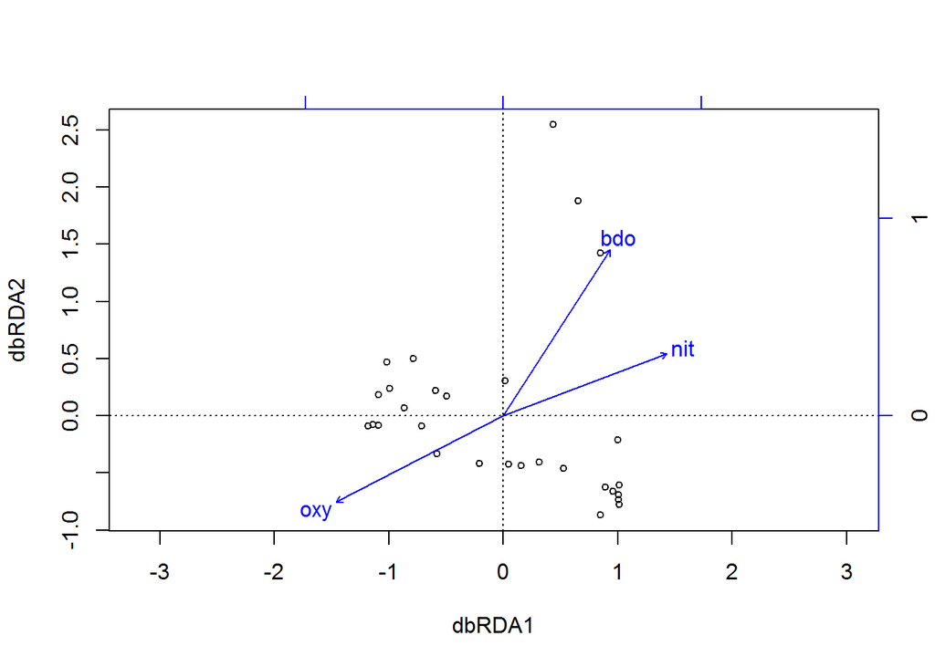

```r
ordiplot(doubs.dbrda)
```

```r
# Permutation tests to evaluate significance
permutest(doubs.dbrda, permutations = 999)
```

```
##
## Permutation test for dbrda
##
## Permutation: free
## Number of permutations: 999
##
## Call: dbrda(formula = fish.db ~ oxy + bdo + nit, data =
## as.data.frame(env.chem))
## Permutation test for all constrained eigenvalues
## Pseudo-F:     10.2619 (with 3, 25 Degrees of Freedom)
## Significance:     0.001
```

```r
#P <= 0.001
envfit(doubs.dbrda, env.chem[,c(4,6,7)], perm = 999)
```

```
##
## ***VECTORS
##
##       dbRDA1   dbRDA2     r2 Pr(>r)
## nit  0.87724  0.48005 0.6431  0.001 ***
## oxy -0.82864 -0.55979 0.7656  0.001 ***
## bdo  0.55603  0.83116 0.8939  0.001 ***
## ---
## Signif. codes:  0 '***' 0.001 '**' 0.01 '*' 0.05 '.' 0.1 ' ' 1
## Permutation: free
## Number of permutations: 999
```

```r
# Calc xplained variation
dbrda.explainvar1 <- round(doubs.dbrda$CCA$eig[1] /sum(c(doubs.dbrda$CCA$eig, doubs.dbrda$CA$eig)), 3) * 100
dbrda.explainvar2 <- round(doubs.dbrda$CCA$eig[2] /sum(c(doubs.dbrda$CCA$eig, doubs.dbrda$CA$eig)), 3) * 100
print(dbrda.explainvar1+dbrda.explainvar2)
```

```
## dbRDA1
##   51.6
```

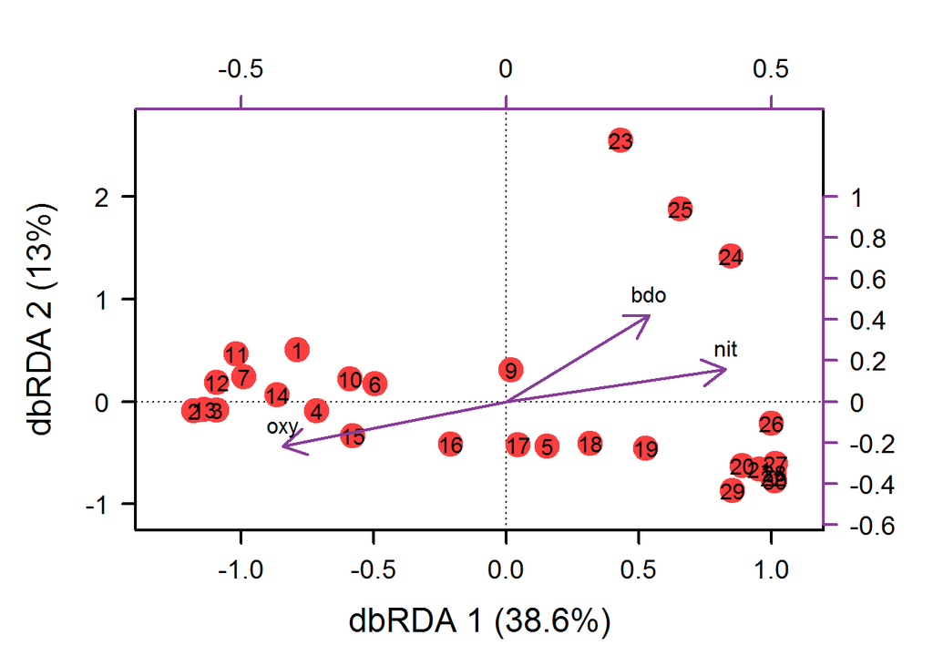

```r
#first two axes explain 51.6% of variance

# Define Plot Parameters
par(mar = c(5, 5, 4, 4) + 0.1)
# Initiate Plot
plot(scores(doubs.dbrda, display = "wa"), xlim = c(-1.3, 1.1), ylim = c(-1.1, 2.7),
xlab = paste("dbRDA 1 (", dbrda.explainvar1, "%)", sep = ""), ylab = paste("dbRDA 2 (", dbrda.explainvar2, "%)", sep = ""), pch = 16, cex = 2.0, type = "n", cex.lab = 1.5, cex.axis = 1.2, axes = FALSE)
# Add Axes
axis(side = 1, labels = T, lwd.ticks = 2, cex.axis = 1.2, las = 1)
axis(side = 2, labels = T, lwd.ticks = 2, cex.axis = 1.2, las = 1)
abline(h = 0, v = 0, lty = 3)
box(lwd = 2)
# points & labels
points(scores(doubs.dbrda, display = "wa"), pch = 19, cex = 2.5, bg = "gray", col = "#fc3e3f")
text(scores(doubs.dbrda, display = "wa"), labels = row.names(scores(doubs.dbrda, display = "wa")))
# envtl Vectors
vectors <- scores(doubs.dbrda, display = "bp")
#row.names(vectors) <- rownames(vectors)

arrows(0, 0, vectors[,1], vectors[, 2],
lwd = 2, lty = 1, length = 0.2, col = "#883c9a")
text(vectors[,1], vectors[, 2], pos = 3, labels = row.names(vectors))
axis(side = 3, lwd.ticks=2, cex.axis=1.2, las = 1, col = "#883c9a", lwd = 2.2, at = pretty(range(vectors[, 1])) * 2, labels = pretty(range(vectors[, 1])))
axis(side = 4, lwd.ticks=2, cex.axis=1.2, las = 1, col = "#883c9a", lwd = 2.2, at = pretty(range(vectors[, 2])) * 2, labels = pretty(range(vectors[, 2])))
```

```r
#okay, it worked...
```

*Question 10*: Based on the constrained ordination, what are the environmental variables (or groups of correlated variables) that seem to be contributing to variation in fish community structure?

> *Answer 10*: The constrained ordination was able to explain 51.6% of the variance using just the nit, oxy, and bdo variables. All these variables were highly significant (P<0.005) in the lowest AIC constrained ordination model.

### iii. Variation Partitioning

In the code chunk below,

1. Create a matrix model of the selected environmental variables,
2. Create a matrix model of the selected PCNM axes,
3. Perform constrained and partial constrained ordinations using the spatial and environmental models you just created,
4. Test the significance of each of your constrained ordinations using permutation tests,
5. Partition the variation among sites into the relative importance of space, environment, spatially structured environment, and residuals,
6. Plot the variation partitioning output to visualize it.

```r
doubs.dbrda$anova
```

```
##                  R2.adj Df    AIC       F Pr(>F)
## + oxy           0.27727  1 47.939 11.7421  0.002 **
## + bdo           0.40090  1 43.404  6.5716  0.002 **
## + nit           0.49808  1 39.134  6.0340  0.004 **
## <All variables> 0.53033
## ---
## Signif. codes:  0 '***' 0.001 '**' 0.01 '*' 0.05 '.' 0.1 ' ' 1
```

```r
env.mod <- model.matrix(~ oxy + bdo + nit, as.data.frame(env.chem))[,-1]#matrix model for the significant envtl data

#spatial model:
rs <- rowSums(fish)/sum(fish)
doubs.pcnmw <- pcnm(dist(doubs$xy[-8,]), w = rs, dist.ret = T)
doubs.pcnmw$values > 0
```

```
##  [1]  TRUE  TRUE  TRUE  TRUE  TRUE  TRUE  TRUE  TRUE  TRUE  TRUE  TRUE
## [12]  TRUE  TRUE  TRUE  TRUE  TRUE  TRUE FALSE FALSE FALSE FALSE FALSE
## [23] FALSE FALSE FALSE FALSE
```

```r
#pare down the model
doubs.space <- as.data.frame(scores(doubs.pcnmw))
doubs.pcnm.mod0 <- dbrda(fish.db ~ 1, doubs.space)
doubs.pcnm.mod1 <- dbrda(fish.db ~ ., doubs.space)
step.pcnm <- ordiR2step(doubs.pcnm.mod0, doubs.pcnm.mod1, perm.max = 200)
```

```
## Step: R2.adj= 0
## Call: fish.db ~ 1
##
##                  R2.adjusted
## <All variables>  0.626011301
## + PCNM2          0.235370423
## + PCNM3          0.078394885
## + PCNM13         0.065305668
## + PCNM5          0.046185074
## + PCNM6          0.032809156
## + PCNM16         0.030486700
## + PCNM14         0.029680999
## + PCNM9          0.020357410
## + PCNM15         0.013632610
## + PCNM8          0.009411968
## + PCNM1          0.003986221
## + PCNM17         0.002415012
## + PCNM10         0.001326442
## <none>           0.000000000
## + PCNM7         -0.001861430
## + PCNM11        -0.006841522
## + PCNM4         -0.007089863
## + PCNM12        -0.014396973
##
##         Df    AIC     F Pr(>F)
## + PCNM2  1 49.574 9.619  0.002 **
## ---
## Signif. codes:  0 '***' 0.001 '**' 0.01 '*' 0.05 '.' 0.1 ' ' 1
##
## Step: R2.adj= 0.2353704
## Call: fish.db ~ PCNM2
##
##                 R2.adjusted
## <All variables>   0.6260113
## + PCNM3           0.3429270
## + PCNM5           0.3057368
## + PCNM1           0.2885396
## + PCNM16          0.2786746
## + PCNM14          0.2744520
## + PCNM15          0.2692809
```

[output cut: 176 more lines]

```
## + PCNM11          0.5978305
## + PCNM4           0.5963667
## + PCNM14          0.5932113
## - PCNM6           0.5767968
## - PCNM13          0.5495723
## - PCNM16          0.5475140
## - PCNM1           0.5362957
## - PCNM3           0.5092539
## - PCNM5           0.4965968
## - PCNM2           0.2824470
##
##         Df    AIC     F Pr(>F)
## + PCNM8  1 34.219 2.151   0.09 .
## ---
## Signif. codes:  0 '***' 0.001 '**' 0.01 '*' 0.05 '.' 0.1 ' ' 1
```

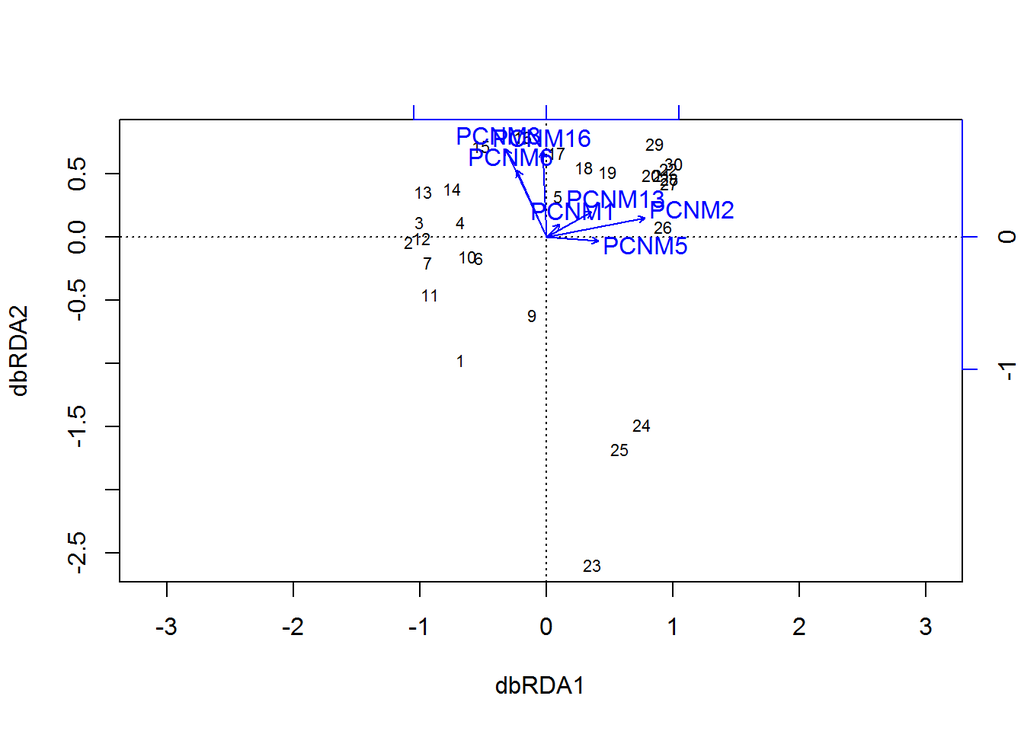

```r
#biplot
plot(step.pcnm)#it's convoluted
```

```r
step.pcnm$anova
```

```
##                  R2.adj Df    AIC      F Pr(>F)
## + PCNM2         0.23537  1 49.574 9.6190  0.002 **
## + PCNM3         0.34293  1 46.083 5.4196  0.004 **
## + PCNM5         0.40760  1 43.941 3.8385  0.010 **
## + PCNM1         0.47215  1 41.411 4.0570  0.010 **
## + PCNM13        0.52124  1 39.346 3.4612  0.010 **
## + PCNM16        0.57680  1 36.480 4.0192  0.008 **
## + PCNM6         0.60431  1 35.182 2.5296  0.038 *
## <All variables> 0.62601
## ---
## Signif. codes:  0 '***' 0.001 '**' 0.01 '*' 0.05 '.' 0.1 ' ' 1
```

```r
#spatial model with only the PCNMs indicated in the lowest AIC model
space.mod <- model.matrix(~ PCNM2 + PCNM3 + PCNM5 + PCNM1 + PCNM13 + PCNM16 + PCNM6, doubs.space)[,-1]

#constrained ordinations
doubs.total.env <- dbrda(fish.db ~ env.mod)
doubs.total.space <- dbrda(fish.db ~ space.mod)
#partial constrained ordination stt one varb is controlled for
doubs.env.cond.space <- dbrda(fish.db ~ env.mod + Condition(space.mod))
doubs.space.cond.env <- dbrda(fish.db ~ space.mod + Condition(env.mod))
#simulations for p-value testing
permutest(doubs.env.cond.space, permutations = 999)
```

```
##
## Permutation test for dbrda
##
## Permutation: free
## Number of permutations: 999
##
## Call: dbrda(formula = fish.db ~ env.mod + Condition(space.mod))
## Permutation test for all constrained eigenvalues
## Pseudo-F:     4.423025 (with 3, 18 Degrees of Freedom)
## Significance:     0.001
```

```r
permutest(doubs.space.cond.env, permutations = 999)
```

```
##
## Permutation test for dbrda
##
## Permutation: free
## Number of permutations: 999
##
## Call: dbrda(formula = fish.db ~ space.mod + Condition(env.mod))
## Permutation test for all constrained eigenvalues
## Pseudo-F:     4.174109 (with 7, 18 Degrees of Freedom)
## Significance:     0.001
```

```r
permutest(doubs.total.env, permutations = 999)
```

```
##
## Permutation test for dbrda
##
## Permutation: free
## Number of permutations: 999
##
## Call: dbrda(formula = fish.db ~ env.mod)
## Permutation test for all constrained eigenvalues
## Pseudo-F:     10.2619 (with 3, 25 Degrees of Freedom)
## Significance:     0.001
```

```r
permutest(doubs.total.space, permutations = 999)
```

```
##
## Permutation test for dbrda
##
## Permutation: free
## Number of permutations: 999
##
## Call: dbrda(formula = fish.db ~ space.mod)
## Permutation test for all constrained eigenvalues
## Pseudo-F:     7.108896 (with 7, 21 Degrees of Freedom)
## Significance:     0.001
```

```r
#all are significant, P <= 0.001
#visualize proportions of variancle explained by each type of variables
doubs.varpart <- varpart(fish.db, env.mod, space.mod)
doubs.varpart
```

```
##
## Partition of squared Bray distance in dbRDA
##
## Call: varpart(Y = fish.db, X = env.mod, space.mod)
##
## Explanatory tables:
## X1:  env.mod
## X2:  space.mod
##
## No. of explanatory tables: 2
## Total variation (SS): 6.7621
## No. of observations: 29
##
## Partition table:
##                      Df R.squared Adj.R.squared Testable
## [a+b] = X1            3   0.55186       0.49808     TRUE
## [b+c] = X2            7   0.70323       0.60431     TRUE
## [a+b+c] = X1+X2      10   0.82917       0.73426     TRUE
## Individual fractions
## [a] = X1|X2           3                 0.12995     TRUE
## [b]                   0                 0.36813    FALSE
## [c] = X2|X1           7                 0.23618     TRUE
## [d] = Residuals                         0.26574    FALSE
## ---
## Use function 'capscale' to test significance of fractions of interest
```

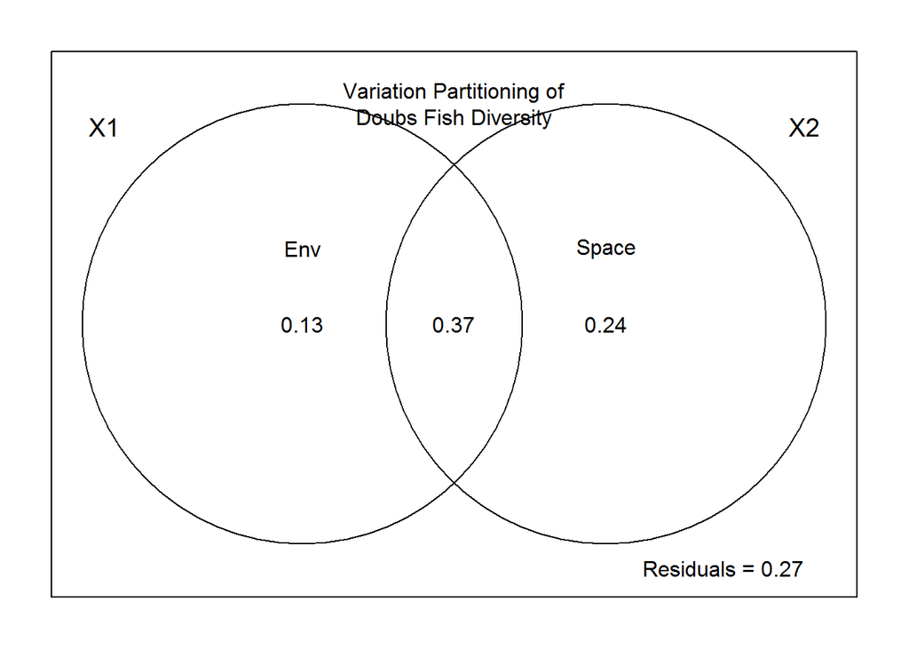

```r
par(mar = c(2,2,2,2))
plot(doubs.varpart)
text(1, 0.25, "Space")
text(0, 0.25, "Env")
mtext("Variation Partitioning of\nDoubs Fish Diversity", side = 3, line = -3)
```

*Question 11*: Interpret the variation partitioning results.

> *Answer 11*: The majority (73-74%) of the variance can be explained by environment and/or space. The largest portion (37%) is explained by spatially structured environment factors. Space alone explained more variation (24%) than environment alone did (13%).

> This indicates that the environmental variables are correlated with geographic location. When this is taken into account, the model can make better predictions about community compositions.

## SYNTHESIS

Load the dataset you are using for your project. Perform an ordination to visualize your dataset. Using this ordination, develop some hypotheses relevant to $\beta$-diversity and identify the appropriate tools you would use to test them.

```r
plant<-read.csv("C:\\Users\\rmoge\\GitHub\\QB2017_DivPro\\Data\\HF_plants.csv")
#print(dim(plant))
#print(names(plant))

#install.packages("dplyr")
require(dplyr)
```

```r
plants.sortedT<-arrange(plant, treatment)
plants.sortedY<-arrange(plants.sortedT,year)
plants.sortedP<-arrange(plants.sortedY,plot)
my2009plants.sortedY<-filter(plants.sortedY, year==2009)
dim(my2009plants.sortedY)
```

```
## [1] 24 43
```

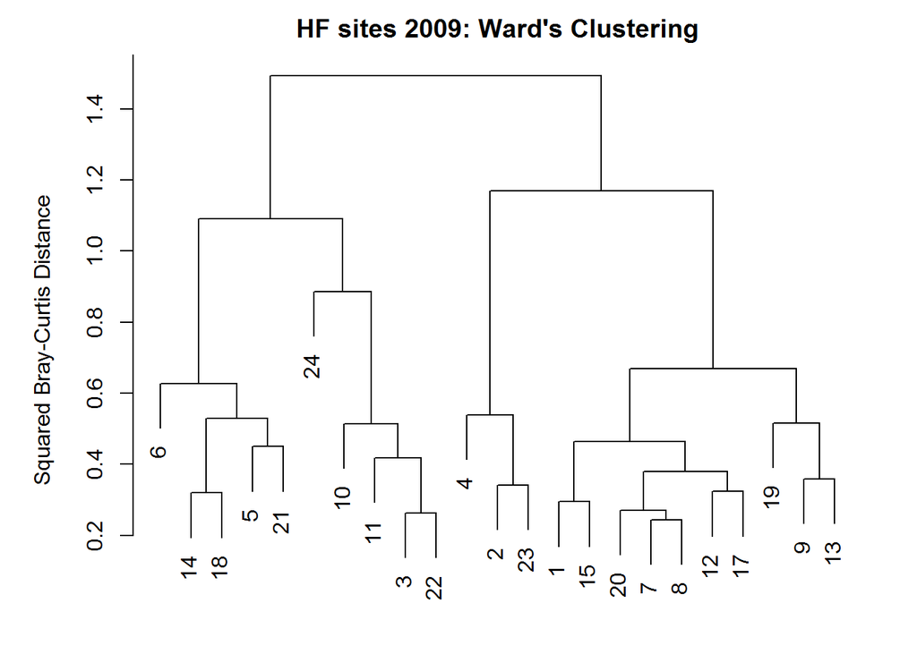

```r
sbs2009plants.sortedYt<-my2009plants.sortedY[4:43]
sbs2009plants.sortedYtt<-sbs2009plants.sortedYt[-16,]

soilenv<-read.csv("C:\\Users\\rmoge\\GitHub\\QB2017_DivPro\\Data\\HF_soilresp.csv")
my2009soilenv<-filter(soilenv,year==2009,day==14,month==1)
temporary_soil<-my2009soilenv[-9]
sbs2009soilenv<-as.matrix(temporary_soil[8:11])

# Calculate Bray-Curtis
#plant.db <- vegdist(sbs2009plants.sortedYt, method = "bray")
#plant.db
plant.db <- vegdist(as.matrix(sbs2009plants.sortedYtt), method = "bray", upper = TRUE, diag = TRUE)
plant.ward <- hclust(plant.db, method = "ward.D2")#now visualize phylogenetically
par(mar = c(1, 5, 2, 2) + 0.1)#set up display settings
plot(plant.ward, main = "HF sites 2009: Ward's Clustering",ylab = "Squared Bray-Curtis Distance")#plot the tree
```

```r
#I will try to make sense of the clustering based on known treatments that were applied.
#Unfortunately 19;9;13 are all different treatments.
#4;2;23 are none controls, but each is a different experimental treatment.
#6;5;14;18;21 run the gamut of treatments.
#10;11;3;22 are all non-controls, but 24 is a control plot
#12;17 are not the same treatment.
#20;7;8 are not the same treatment.
#1;15 are not the same treatment.
#I am not able to detect any categorical patterns in the clustering.


#Next do PCoA
plant.pcoa <- cmdscale(plant.db, eig = TRUE, k = 3)#do the PCoA
str(plant.pcoa)
```

```
## List of 5
##  $ points: num [1:23, 1:3] -0.00742 -0.43847 0.28123 -0.36578 0.24496 ...
##   ..- attr(*, "dimnames")=List of 2
##   .. ..$ : chr [1:23] "1" "2" "3" "4" ...
##   .. ..$ : NULL
##  $ eig   : num [1:23] 1.356 0.818 0.647 0.526 0.333 ...
##  $ x     : NULL
##  $ ac    : num 0
##  $ GOF   : num [1:2] 0.57 0.598
```

```r
explainvar1 <- round(plant.pcoa$eig[1] / sum(plant.pcoa$eig), 3) * 100#for each of the first three eigenvalues, assess what proportion of variance it explains
explainvar2 <- round(plant.pcoa$eig[2] / sum(plant.pcoa$eig), 3) * 100
explainvar3 <- round(plant.pcoa$eig[3] / sum(plant.pcoa$eig), 3) * 100
sum.eig <- sum(explainvar1, explainvar2, explainvar3)#total amt explained in these 3 dimensions

par(mar = c(5, 5, 1, 2) + 0.1)#structure the figure output
# Initiate Plot
plot(plant.pcoa$points[ ,1], plant.pcoa$points[ ,2], ylim = c(-0.2, 0.7), xlab = paste("PCoA 1 (", explainvar1, "%)", sep = ""), ylab = paste("PCoA 2 (", explainvar2, "%)", sep = ""), pch = 16, cex = 2.0, type = "n", cex.lab = 1.5, cex.axis = 1.2, axes = FALSE)
# Add Axes
axis(side = 1, labels = T, lwd.ticks = 2, cex.axis = 1.2, las = 1)
axis(side = 2, labels = T, lwd.ticks = 2, cex.axis = 1.2, las = 1)
abline(h = 0, v = 0, lty = 3)
box(lwd = 2)
# Add Points & Labels
points(plant.pcoa$points[ ,1], plant.pcoa$points[ ,2],
pch = 19, cex = 3, bg = "#fc066e", col = "#fc066e")
text(plant.pcoa$points[ ,1], plant.pcoa$points[ ,2],
labels = row.names(plant.pcoa$points))
#Now IDfy the most influential spp
plantREL <- sbs2009plants.sortedYtt
  for(i in 1:nrow(sbs2009plants.sortedYtt)){
    plantREL[i, ] = sbs2009plants.sortedYtt[i, ] / sum(sbs2009plants.sortedYtt[i, ])
    }
plant.pcoa <- add.spec.scores(plant.pcoa,plantREL,method = "pcoa.scores")
```

[output not shown]